# 딥 러닝 (Deel Learning) 개요

- 최근 인공 신경망을 복잡하게 쌓아 올린 딥 러닝이 다른 머신러닝 방법들을 뛰어넘는 성능을 보여주는 사례가 늘면서, 전통적인 머신 러닝과 딥 러닝을 구분해서 이해해야 한다는 의견 증가

## 퍼셉트론 (Perceptron)

- 퍼셉트론(Perceptron)은 프랑크 로젠블라트(Frank Rosenblatt)가 1957년에 제안한 초기 형태의 인공 신경망으로 다수의 입력으로부터 하나의 결과를 내보내는 알고리
- 퍼셉트론은 실제 뇌를 구성하는 신경 세포 뉴런의 동작과 유사
- 뉴런은 가지돌기에서 신호를 받아들이고, 이 신호가 일정치 이상의 크기를 가지면 축삭돌기를 통해서 신호를 전달

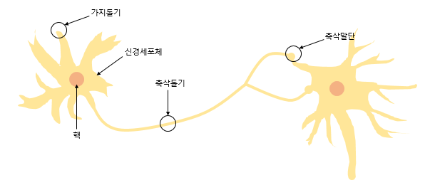

- **신경 세포 뉴런의 입력 신호와 출력 신호가, 퍼셉트론에서 각각 입력값과 출력값에 해당**
  - $x$ 는 입력값을 의미하며, $w$는 가중치(Weight), $y$는 출력
  - 그림 안의 원은 인공 뉴런에 해당
  - 실제 신경 세포 뉴런에서의 신호를 전달하는 축삭돌기의 역할을 퍼셉트론에서는 가중치가 대신
  - 각각의 인공 뉴런에서 보내진 입력값 $x$는 각각의 가중치 $w$

  와 함께 종착지인 인공 뉴런에 전달

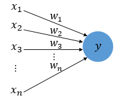

- 각각의 입력값에는 각각의 가중치가 존재하는데, **이때 가중치의 값이 크면 클수록 해당 입력 값이 중요하다는 것을 의미**

#### **계단함수(Step function)**

- **활성화 함수 (Activation Function) 중 하나**
- 초기 인공 신경망 모델인 퍼셉트론은 활성화 함수로 계단 함수를 사용
- **각 입력값이 가중치와 곱해져서 인공 뉴런에 보내지고, 각 입력값과 그에 해당되는 가중치의 곱의 전체 합이 임계치(threshold)를 넘으면**, 종착지에 있는 인공 뉴런은 출력 신호로서 1을 출력하고, 그렇지 않을 경우에는 0을 출력

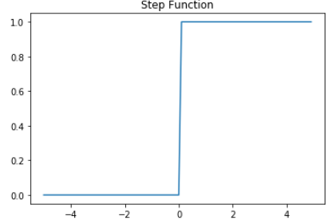

$$if \sum_i^{n} w_{i}x_{i}\ ≥ \theta → y=1$$$$if \sum_i^{n} w_{i}x_{i}\ < \theta → y=0\;$$$$(\theta = 임계점)$$

- 위의 식에서 임계치를 좌변으로 넘기고 편향 $b$ (bias)로 표현 가능
  - 편향 $b$ 또한 퍼셉트론의 입력으로 사용
  - 보통 그림으로 표현할 때는 입력값이 1로 고정되고 편향 $b$

가 곱해지는 변수로 표현

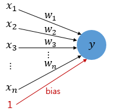

$$if \sum_i^{n} w_{i}x_{i} + b ≥ 0 → y=1$$$$if \sum_i^{n} w_{i}x_{i} + b < 0 → y=0$$

### 단층 퍼셉트론(Single-Layer Perceptron)

- 퍼셉트론은 단층 퍼셉트론과 다층 퍼셉트론으로 구분
- 단층 퍼셉트론은 값을 보내는 단계과 값을 받아서 출력하는 두 단계로만 구성.
  - **이때 이 각 단계를 보통 층(layer)이라고 부르며, 이 두 개의 층을 입력층(input layer)과 출력층(output layer)으로 부름**

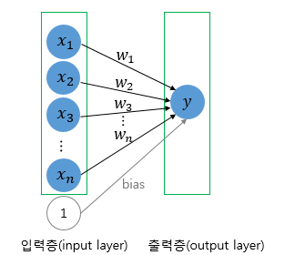

#### **게이트(gate)**

- 0과 1을 입력해 하나의 값을 출력하는 컴퓨터의 회로
- **단층 퍼셉트론을 이용하면 AND, NAND, OR 게이트는 구현가능**
- 게이트 연산에 쓰이는 것은 두 개의 입력값과 하나의 출력값
- **AND 게이트** : 두 개의 입력값 $x_1$, $x_2$이 각각 0 또는 1의 값을 가질 수 있으면서 **모두 1인 경우에만 출력값

가 1이 나오는 구조**

```python
def AND_gate(x1, x2):
    w1 = 0.5
    w2 = 0.5
    b = -0.7
    result = x1*w1 + x2*w2 + b
    if result <= 0:
        return 0
    else:
        return 1
```

```python
AND_gate(0, 0), AND_gate(0, 1), AND_gate(1, 0), AND_gate(1, 1)
```

```
(0, 0, 0, 1)
```

- **NAND 게이트** : 두 개의 입력값 $x_1$, $x_2$이 모두 1인 경우에만 출력값 0이 나오는 구조

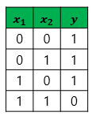

```python
def NAND_gate(x1, x2):
    w1 = -0.5
    w2 = -0.5
    b = 0.7
    result = x1*w1 + x2*w2 + b
    if result <= 0:
        return 0
    else:
        return 1
```

```python
NAND_gate(0, 0), NAND_gate(0, 1), NAND_gate(1, 0), NAND_gate(1, 1)
```

```
(1, 1, 1, 0)
```

- **OR 게이트** : 두 개의 입력값 $x_1$, $x_2$ 한개 이상이 1인 경우에 출력값 1이 나오는 구조

```python
def OR_gate(x1, x2):
    w1 = 0.6
    w2 = 0.6
    b = -0.5
    result = x1*w1 + x2*w2 + b
    if result <= 0:
        return 0
    else:
        return 1
```

```python
OR_gate(0, 0), OR_gate(0, 1), OR_gate(1, 0), OR_gate(1, 1)
```

```
(0, 1, 1, 1)
```

#### 단층 퍼셉트론은 AND 게이트, NAND 게이트, OR 게이트를 구현할 수 있으나, XOR 게이트는 구현할 수 없음

- **XOR 게이트** : 입력값 두 개가 서로 다른 값을 갖고 있을때에만 출력값이 1이 되고, 입력값 두 개가 서로 같은 값을 가지면 출력값이 0이 되는 게이트
- 아무리 수많은 가중치와 편향을 넣어봐도 XOR 게이트를 구현하는 것은 불가능
- **단층 퍼셉트론은 직선 하나로 두 영역을 나눌 수 있는 문제에 대해서만 구현이 가능하기 때문**
- AND 게이트에 대한 단층 퍼셉트론 시각화

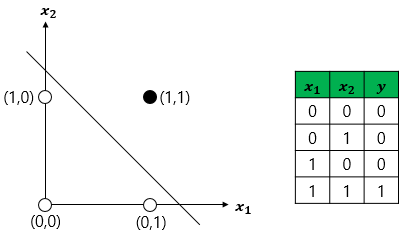

- NAND 게이트와 OR 게이트에 대한 시각화

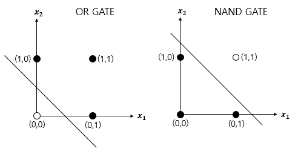

- XOR 게이트는 입력값 두 개가 서로 다른 값을 갖고 있을때에만 출력값이 1이 되고, 입력값 두 개가 서로 같은 값을 가지면 출력값이 0이 되는 게이트
  - **하얀색 원과 검은색 원을 직선 하나로 나누는 것은 불가능하므로 단층 퍼셉트론으로는 XOR 게이트를 구현할 수 없음 위의 (적어도 두 개의 선이 필요)**
  - 이를 해결하기 위해 다층 퍼셉트론필요

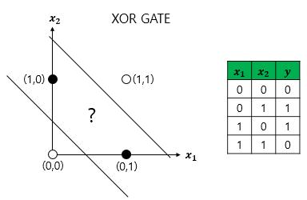

### 다층 퍼셉트론(MultiLayer Perceptron, MLP)

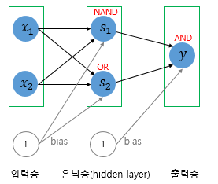

- XOR 문제나 기타 복잡한 문제를 해결하기 위해서 다층 퍼셉트론은 중간에 수많은 은닉층을 더 추가할 수 있음
- **심층 신경망(Deep Neural Network, DNN)** : 은닉층이 2개 이상인 신경망을
  - 심층 신경망은 다층 퍼셉트론만 이외의, 여러 변형된 다양한 신경망들도 은닉층이 2개 이상이 되면 심층 신경망

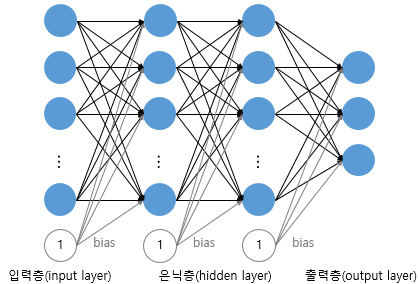

#### 기계가 가중치를 스스로 찾아내도록 자동화하는 것이 머신 러닝에서 말하는 **훈련(training)**또는 **학습(learning) 단계에 해당**됩니다.

- 손실 함수(Loss function)와 옵티마이저(Optimizer) 사용
- **만약 학습을 시키는 인공 신경망이 심층 신경망일 경우에는 이를 심층 신경망을 학습시킨다고 하여, 딥 러닝(Deep Learning)**

## 인공 신경망(Artificial Neural Network)

### 피드 포워드 신경망(Feed-Forward Neural Network, FFNN)

- **다층 퍼셉트론(MLP)과 같이 오직 입력층에서 출력층 방향으로 연산이 전개되는 신경망**

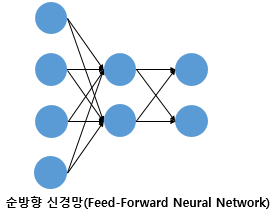

- FFNN에 속하지 않는 RNN 신경망 :
  - **RNN신경망은 은닉층의 출력값을 출력층으로도 값을 보내지만, 동시에 은닉층의 출력값이 다시 은닉층의 입력으로 사용되기도 함**

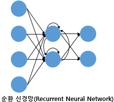

### 전결합층(Fully-connected layer, FC, Dense layer)

- 다층 퍼셉트론은 은닉층과 출력층에 있는 모든 뉴런은 바로 이전 층의 모든 뉴런과 연결되어 있음
- **전결합층(Fully-connected layer) (or 완전연결층, 밀집층(Dense layer))** : 어떤 층의 모든 뉴런이 이전 층의 모든 뉴런과 연결돼 있는 층

### 활성화 함수(Activation Function)

- **은닉층과 출력층의 뉴런에서 출력값을 결정하는 함수**
  - 계단 함수는 활성화 함수의 하나

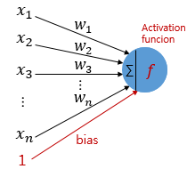

#### (1) 활성화 함수의 특징 - 비선형 함수(Nonlinear function)

- **활성화 함수의 특징은 선형 함수가 아닌 비선형 함수**
  - 인공 신경망의 능력을 높이기 위해서는 은닉층을 계속해서 추가
  - 만약 활성화 함수로 선형 함수를 사용하게 되면 은닉층을 쌓는 것이 불가
  - 활성화 함수가 $f(x)=wx$ 라고 가정할 시, 은닉층을 2개를 추가한다면 출력층을 포함해서 $y(x) = f(f(f(x)))$
  - 이를 식으로 표현하면 $w × w × w × x$ $\rightarrow$ $y(x) = kx$
  - 결국, **선형 함수로 은닉층을 여러번 추가하더라도 1회 추가한 것과 차이가 없음**
- 하지만 종종 활성화 함수를 사용하지 않는 층을, 비선형 층들과 함께 인공 신경망의 일부로서 추가하는 경우가 존재
  - 선형 함수를 사용한 층을, 활성화 함수를 사용하는 은닉층과 구분하기 위해서 **선형층(linear layer)이나 투사층(projection layer)** 등으로 표현
  - 임베딩 층에는 활성화 함수가 존재하지 않음
  - 활성화 함수를 사용하는 일반적인 은닉층을, 선형층과 대비되는 표현을 사용하면 비선형층(nonlinear layer)

#### (2) 계단 함수(Step function)

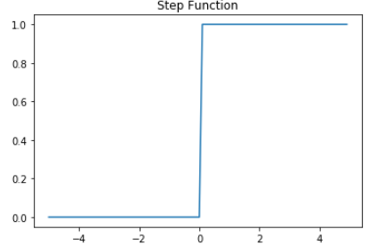

```python
import numpy as np
import matplotlib.pyplot as plt
```

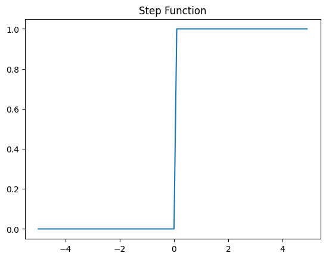

```python
def step(x):
    return np.array(x > 0, dtype=np.int)
x = np.arange(-5.0, 5.0, 0.1) # -5.0부터 5.0까지 0.1 간격 생성
y = step(x)
plt.title('Step Function')
plt.plot(x,y)
plt.show()
```

#### (3) 시그모이드 함수(Sigmoid function)와 기울기 소실

- **인공 신경망은 입력에 대해서 순전파(forward propagation) 연산**
- **순전파 연산을 통해 나온 예측값과 실제값의 오차를 손실 함수(loss function)을 통해 계산**
- **손실(오차. loss)을 미분을 통해서 기울기(gradient)를 구하고, 이를 통해 출력층에서 입력층 방향으로 가중치와 편향을 업데이트 하는 과정인 역전파(back propagation)를 수행**
  - **역전파 : 인공 신경망에서 출력층에서 입력층 방향으로 가중치와 편향을 업데이트 하는 과정**
  - 역전파 과정에서 인공 신경망은 경사 하강법을 사용

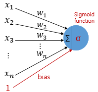

- 시그모이드 함수의 출력값이 0 또는 1에 가까워지면, 그래프의 기울기가 완만해지는 모습

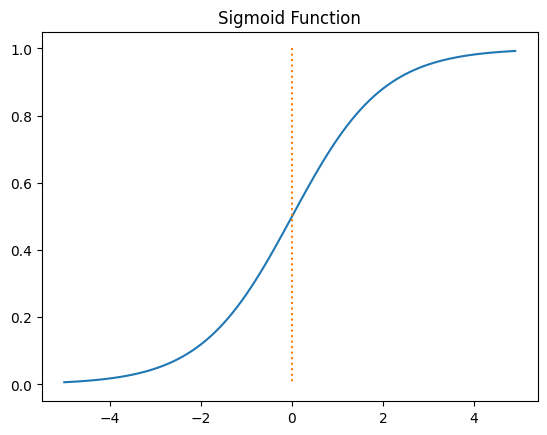

```python
def sigmoid(x):
    return 1/(1+np.exp(-x))
x = np.arange(-5.0, 5.0, 0.1)
y = sigmoid(x)

plt.plot(x, y)
plt.plot([0,0],[1.0,0.0], ':') # 가운데 점선 추가
plt.title('Sigmoid Function')
plt.show()
```

#### 기울기 소실(Vanishing Gradient) 문제

- 기울기가 완만해지는 구간을 주황색, 그렇지 않은 구간을 초록색으로 표현
  - **주황색 구간에서는 미분값이 0에 가까운 아주 작은 값, 초록색 구간에서의 미분값은 최대값이 0.25 $\rightarrow$ 시그모이드 함수를 미분한 값은 적어도 0.25 이하의 값**
  - **시그모이드 함수를 활성화 함수로하는 인공 신경망의 층을 쌓는다면, 가중치와 편향을 업데이트 하는 과정인 역전파 과정에서 0에 가까운 값이 누적해서 곱해지게 되면서, 앞단에는 기울기(미분값)가 잘 전달되지 않음**

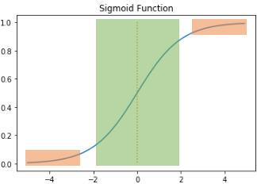

- **시그모이드 함수를 사용하는 은닉층의 개수가 다수가 될 경우에는 0에 가까운 기울기가 계속 곱해지면서, 앞단에서는 거의 기울기를 전파받을 수 없음** (매개변수 $w$가 업데이트 되지 않아 학습이 되지 않음)
  - 은닉층이 깊은 신경망에서 기울기 소실 문제로 인해,**오차 역전파 과정에서 출력층과 가까운 은닉층에서는 기울기가 잘 전파되지만, 앞단으로 갈수록 기울기가 제대로 전파되지 않음**
  - **결론적으로 시그모이드 함수의 은닉층에서의 사용은 지양 되며, 시그모이드 함수는 주로 이진 분류를 위해 출력층에서 사용**

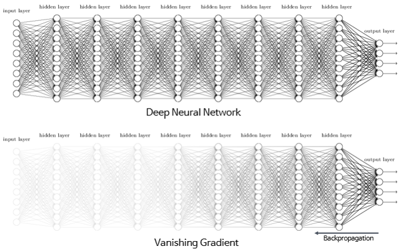

#### 하이퍼볼릭탄젠트 함수(Hyperbolic tangent function)

- **하이퍼볼릭탄젠트 함수는 -1과 1에 가까운 출력값을 출력할 때, 시그모이드 함수와 같은 문제가 발생**
- **그러나 하이퍼볼릭탄젠트 함수의 경우에는 시그모이드 함수와는 달리 0을 중심으로 하고있으며**, **하이퍼볼릭탄젠트 함수를 미분했을 때의 최대값은 1**
- 미분했을 때 시그모이드 함수보다는 전반적으로 큰 값이 나오게 되며, 시그모이드 함수보다는 기울기 소실 증상이 적음

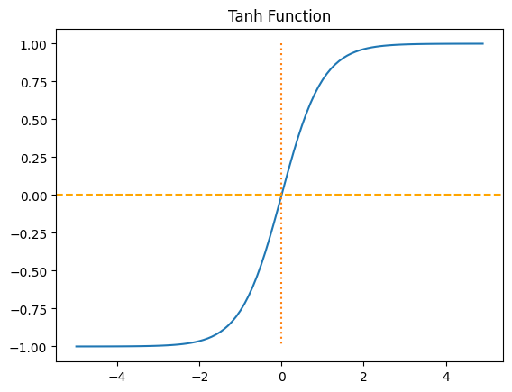

```python
x = np.arange(-5.0, 5.0, 0.1) # -5.0부터 5.0까지 0.1 간격 생성
y = np.tanh(x)

plt.plot(x, y)
plt.plot([0,0],[1.0,-1.0], ':')
plt.axhline(y=0, color='orange', linestyle='--')
plt.title('Tanh Function')
plt.show()
```

#### (5) 렐루 함수(ReLU)

- 렐루 함수는 음수를 입력하면 0을 출력하고, 양수를 입력하면 입력값을 그대로 반환
- **출력값이 특정 양수값에 수렴하지 않으며, 0이상의 입력값의 경우에는 미분값이 항상 1**
- 깊은 신경망의 **은닉층에서 시그모이드 함수보다 훨씬 더 잘 작동**할 뿐만 아니라, **렐루 함수는 시그모이드 함수와 하이퍼볼릭탄젠트 함수와 같이 어떤 연산이 필요한 것이 아니라 단순 임계값이므로 연산 속도도 빠름**
  - 은닉층에서는 ReLU(또는 ReLU 변형) 함수들을 사용하는 것이 일반적
- **하지만 입력값이 음수면 기울기(미분값)도 0**
  - 그리고 이 뉴런은 다시 회생하는 것이 매우 어려움 (죽은 렐루(dying ReLU) 문제)

$$f(x) = max(0, x)$$

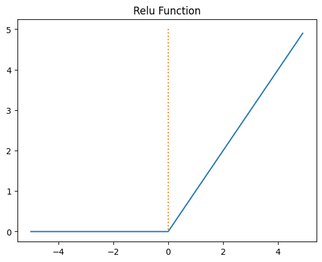

```python
def relu(x):
    return np.maximum(0, x)

x = np.arange(-5.0, 5.0, 0.1)
y = relu(x)

plt.plot(x, y)
plt.plot([0,0],[5.0,0.0], ':')
plt.title('Relu Function')
plt.show()
```

#### (6) 리키 렐루(Leaky ReLU)

- **죽은 렐루를 보완하기 위한 변형 함수는 여러 개가 있지만 여기서는 Leaky ReLU는 입력값이 음수일 경우에 0이 아니라 0.001과 같은 매우 작은 수를 반환**
- $a$ : 하이퍼파라미터, Leaky('새는') 정도를 결정, **입력값의 음수일 때의 기울기. (일반적으로는 0.01의 값)**
  - 입력값이 음수라도 기울기가 0이 되지 않으면 ReLU는 죽지 않음

$$f(x) = max(ax, x)$$

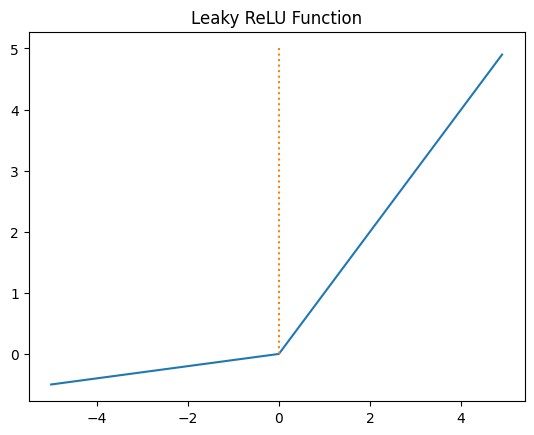

```python
a = 0.1

def leaky_relu(x):
    return np.maximum(a*x, x)

x = np.arange(-5.0, 5.0, 0.1)
y = leaky_relu(x)

plt.plot(x, y)
plt.plot([0,0],[5.0,0.0], ':')
plt.title('Leaky ReLU Function')
plt.show()
```

#### (7) 소프트맥스 함수(Softmax function)

- 소프트맥스 함수는 시그모이드 함수처럼 출력층에서 주로 사용
- 시그모이드 함수가 두 가지 선택지 중 하나를 고르는 이진 분류 (Binary Classification) 문제에 사용된다면, **소프트맥스 함수는 세 가지 이상의 (상호 배타적인) 선택지 중 하나를 고르는 다중 클래스 분류(MultiClass Classification) 문제에 주로 사용**
- 딥 러닝으로 **이진 분류를 할 때는 출력층에 앞서 배운 로지스틱 회귀를 사용**하고, 딥 러닝으로 **다중 클래스 분류 문제를 풀 때는 출력층에 소프트맥스 회귀를 사용**

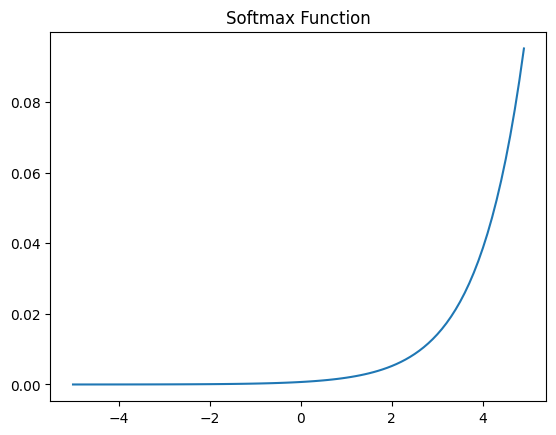

```python
x = np.arange(-5.0, 5.0, 0.1) # -5.0부터 5.0까지 0.1 간격 생성
y = np.exp(x) / np.sum(np.exp(x))

plt.plot(x, y)
plt.title('Softmax Function')
plt.show()
```